# html

## Load Data

```python
import pandas as pd
import numpy as np

Trucks = pd.read_csv('https://storage.googleapis.com/datalynn-datasets/interview-challenge/transportation/Uber_Freight_Pricing/Trucks.csv')
Loads = pd.read_csv('https://storage.googleapis.com/datalynn-datasets/interview-challenge/transportation/Uber_Freight_Pricing/Loads.csv')
Pricing = pd.read_csv('https://storage.googleapis.com/datalynn-datasets/interview-challenge/transportation/Uber_Freight_Pricing/Pricing.csv')
```

### Question 1

**Scenario:** As always, it's critical to start with a clear understanding of our datasets.

- Conduct an exploratory data analysis (EDA) of the `Trucks` and `Loads` datasets. Identify and visualize the most common types of loads, the distribution of truck capacities, and the frequency of trucks operating below 50% capacity.

#### Problem solving ideas and tips:

1. For most common types of loads, group by the type of loads and count the frequencies. A bar chart can be used to visualize this.
2. For the distribution of truck capacities, a histogram or density plot can be insightful.
3. To determine the frequency of trucks operating below 50% capacity, filter the trucks based on the capacity criteria and count the occurrences.

```
           type  count_type
0       general         796
1         heavy         462
2  refrigerated         432
3       fragile         310
```

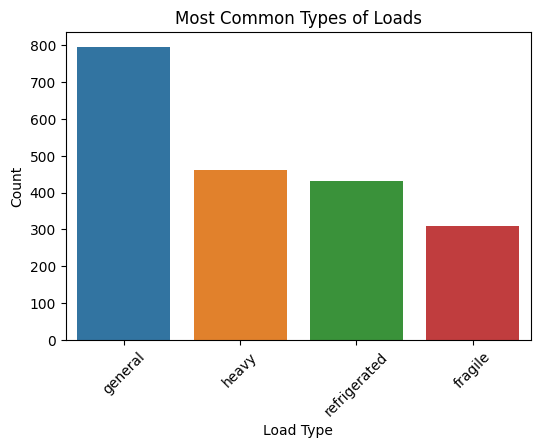

```python
# Convert pandas dataframes to SQL tables using SQLlite3
import sqlite3
import pandas as pd
import matplotlib.pyplot as plt
import seaborn as sns

conn = sqlite3.connect(':memory:')
Trucks.to_sql('Trucks', conn, index=False)
Loads.to_sql('Loads', conn, index=False)

# 1. Most common types of loads
query_loads = "SELECT type, COUNT(type) as count_type FROM Loads GROUP BY type ORDER BY count_type DESC"
most_common_loads = pd.read_sql(query_loads, conn)
print(most_common_loads)

plt.figure(figsize=(6, 4))
sns.barplot(data=most_common_loads, x='type', y='count_type')
plt.title('Most Common Types of Loads')
plt.ylabel('Count')
plt.xlabel('Load Type')
plt.xticks(rotation=45)
plt.show()
```

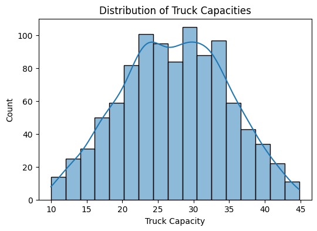

```python
# 2. Distribution of truck capacities
plt.figure(figsize=(6, 4))
sns.histplot(Trucks['truck_capacity'], kde=True)
plt.title('Distribution of Truck Capacities')
plt.xlabel('Truck Capacity')
plt.show()
```

```python
# 3. Frequency of trucks operating below 50% capacity
query_trucks = "SELECT COUNT(*) as count_trucks_below_half FROM Trucks WHERE load_capacity / truck_capacity < 0.5"
trucks_below_half = pd.read_sql(query_trucks, conn)

print(f"Number of trucks operating below 50% capacity: {trucks_below_half['count_trucks_below_half'].iloc[0]}")
```

```
Number of trucks operating below 50% capacity: 380
```

### Question 2

**Scenario:** Recent feedback has shed light on an alarming issue. When Uber Freight's pricing doesn't match demand, loads can remain unserved because shippers find them too expensive, or trucks can go underutilized if they're perceived as overpriced by shippers, leading to inefficiencies on both sides.

- Given the Pricing and Loads datasets, devise a predictive model to anticipate the demand of a load given the load information. How would past price and demand data inform a more dynamic and responsive pricing strategy? Which metrics would you employ to measure the success of the strategy?

#### Problem solving ideas and tips:

1. To devise a predictive model, you would first combine the Loads and Pricing datasets on common columns to get a consolidated view.
2. Use past price and demand data as features. The idea is if you have data about how demand changed in response to various prices in the past, you can use this data to train a model to predict future demand given a price.
3. For a predictive model, regression algorithms such as Linear Regression, Decision Trees, or more advanced ones like Gradient Boosting can be employed.
4. Metrics such as Mean Absolute Error (MAE), Root Mean Squared Error (RMSE), and R-squared can be used to measure the model's accuracy and effectiveness.

```python
from sklearn.model_selection import train_test_split
from sklearn.ensemble import GradientBoostingRegressor
from sklearn.metrics import mean_absolute_error, mean_squared_error, r2_score

# Combine the Pricing and Loads datasets
merged_data = pd.merge(Pricing, Loads, on=["load_id"])

# Feature engineering: Consider past price and demand data.
# For simplicity, assuming merged_data already has columns like 'previous_demand_index' and 'previous_price'

# Features and Target variable
X = merged_data[["type", "weight", "origin", "destination","days_before_deadline"]]
y = merged_data["demand_index"]

# Convert categorical columns to numerical (dummy variables)
X = pd.get_dummies(X, columns=["type", "origin", "destination"])

# Splitting data into training and testing sets
X_train, X_test, y_train, y_test = train_test_split(X, y, test_size=0.2, random_state=42)

# Using Gradient Boosting as the regression model
model = GradientBoostingRegressor()
model.fit(X_train, y_train)

# Predicting on test data
y_pred = model.predict(X_test)

# Evaluation
mae = mean_absolute_error(y_test, y_pred)
rmse = mean_squared_error(y_test, y_pred, squared=False)
r2 = r2_score(y_test, y_pred)

print(f"Mean Absolute Error: {mae}")
print(f"Root Mean Squared Error: {rmse}")
print(f"R Square: {r2}")
```

```
Mean Absolute Error: 0.1531672504703133
Root Mean Squared Error: 0.2159123974819223
R Square: 0.8159469480607277
```

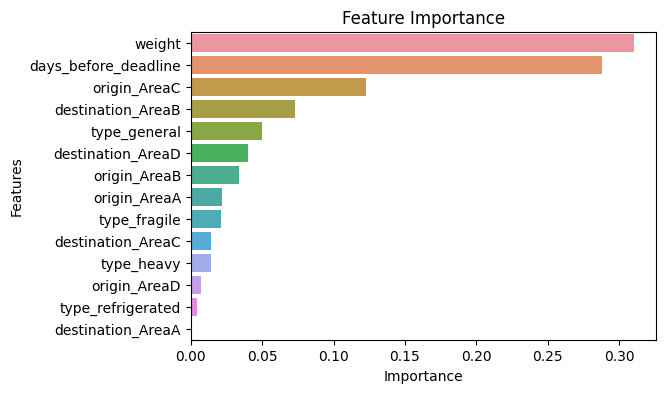

```python
import matplotlib.pyplot as plt
import seaborn as sns

# Extracting feature importance from the model
feature_importance = model.feature_importances_

# Create a DataFrame for the feature importance
features_df = pd.DataFrame({
    'Features': X_train.columns,
    'Importance': feature_importance
})

# Sort the DataFrame by importance
features_df = features_df.sort_values(by='Importance', ascending=False)

# Plot
plt.figure(figsize=(6, 4))
sns.barplot(x='Importance', y='Features', data=features_df)
plt.title('Feature Importance')
plt.show()
```

### Pricing Strategy

**1. Understanding the Problem:** When pricing does not match demand, it introduces inefficiencies:

- **Overpriced Loads**: When loads are priced too high compared to demand, shippers may find them too expensive, causing these loads to remain unserved. This leads to revenue losses and potential loss of shippers to competitors.
- **Underpriced Trucks**: On the flip side, if trucks are perceived as overpriced by shippers, these trucks go underutilized. This means truckers don't earn, and trucks remain idle, leading to operational inefficiencies and costs.

**3. Addressing the Core Issues:**

- **Avoiding Overpriced Loads**: By dynamically adjusting prices based on predicted demand, the likelihood of loads being perceived as too expensive decreases. Special offers, discounts, or incentives can be introduced for loads that historically tend to remain unserved.
- **Preventing Underutilized Trucks**: A similar approach can be used for truck pricing. If certain trucks or routes are consistently underutilized, their pricing can be adjusted downwards. Conversely, for highly sought-after trucks or routes, prices can be slightly increased.

**4. Metrics to Measure Success:**

- **Utilization Rate**: This will measure how well trucks are being used. An increase in this rate indicates fewer idle trucks and more efficient operations.
- **Load Service Rate**: This metric will determine how many loads get served compared to those that remain unserved. A higher rate is indicative of better matching between pricing and demand.
- **Revenue and Profit Metrics**: Monitor the revenue and profit before and after implementing the dynamic pricing strategy. An effective pricing strategy should lead to increased revenue and profit margins.
- **Customer Retention and Acquisition**: Monitor the number of shippers that continue to use the service (retention) and new shippers that start using the service (acquisition). A good pricing strategy will attract and retain more customers.

In conclusion, by leveraging predictive modeling, the dynamic pricing strategy becomes data-driven, addressing the core issues of unserved loads and underutilized trucks. It ensures that pricing is always in line with demand, maximizing efficiency, revenue, and customer satisfaction.

## Question 3

**Scenario** Given the success of loyalty programs in various Uber domains, the Freight division is considering launching a "Freight Loyalty Pass" for regular shippers.

- Leveraging the historical load and pricing information, how would you shape this loyalty program? What would be the criteria for eligibility, and what kinds of benefits or discounts could be embedded without seriously undermining profits?

**Problem Solving Ideas and Tips:**

Creating a loyalty program is a strategic decision that needs to take into account customer behavior, the company's value proposition, and the financial implications. Given the data from load and pricing information, the following points can guide the loyalty program's design:

1. **Eligibility Criteria**: Based on:
   - **Frequency of Shipments**: Regular shippers might have a certain minimum number of shipments in a specific time period (e.g., monthly, quarterly).
   - **Total Spend**: High-value shippers can be recognized by the total monetary value they bring.
   - **Longevity**: Loyalty can be measured by how long they've been using the service.
2. **Benefits**:
   - **Discounts**: Depending on the margin from the pricing data, offer a percentage off for loyalty pass holders.
   - **Priority Service**: Offer priority booking or guaranteed availability during peak times.
   - **Customized Pricing**: Offer dynamic pricing benefits based on the shipment frequency or volume.
3. **Maintaining Profitability**:
   - **Tiered Program**: Higher benefits for customers who ship more frequently or bring in more value. This ensures high-value customers get significant benefits without offering heavy discounts to infrequent users.
   - **Expiry**: Set benefits to expire after a certain period, encouraging regular shipments.
   - **Volume-based Discounts**: Offer discounts for bulk shipments, which might be more cost-effective in terms of operations.

```python
# Joining Load and Pricing data on load_id
combined_data = Loads.merge(Pricing, on='load_id')

# Creating Shipper data (assuming shipper_id in Loads)
shipper_summary = combined_data.groupby('shipper_id').agg(
    total_shipments=pd.NamedAgg(column='load_id', aggfunc='count'),
    total_spend=pd.NamedAgg(column='price', aggfunc='sum')
)

# Setting thresholds for loyalty program
min_shipments = 10
min_spend = 1000

# Identifying eligible shippers
eligible_shippers = shipper_summary[
    (shipper_summary['total_shipments'] > min_shipments) |
    (shipper_summary['total_spend'] > min_spend)
].copy()

# Estimating potential profit impact
avg_margin = (Pricing['price'] - Pricing['price'].mean() * 0.7).mean() # Assuming 30% margin
potential_discount = avg_margin * 0.05  # Offering a 10% discount as an example
potential_loss = potential_discount * eligible_shippers['total_shipments'].sum()

# Benefits
tier_1_discount = 0.10
tier_2_discount = 0.05
tier_3_discount = 0.02

eligible_shippers['loyalty_tier'] = pd.cut(
    eligible_shippers['total_spend'],
    bins=[0, 2000, 5000, float('inf')],
    labels=['Tier 3', 'Tier 2', 'Tier 1']
)

eligible_shippers['discount'] = eligible_shippers['loyalty_tier'].map({
    'Tier 1': tier_1_discount,
    'Tier 2': tier_2_discount,
    'Tier 3': tier_3_discount
})
print("Potential Loss:", potential_loss)

eligible_shippers
```

```
Potential Loss: 15094.490244966448
```

| shipper_id | total_shipments | total_spend | loyalty_tier | discount |
| --- | --- | --- | --- | --- |
| 0 | 7 | 3933.221477 | Tier 2 | 0.05 |
| 1 | 3 | 1406.040268 | Tier 3 | 0.02 |
| 2 | 3 | 2222.147651 | Tier 2 | 0.05 |
| 3 | 6 | 2353.020134 | Tier 2 | 0.05 |
| 4 | 3 | 1437.919463 | Tier 3 | 0.02 |
| ... | ... | ... | ... | ... |
| 493 | 3 | 1565.436242 | Tier 3 | 0.02 |
| 495 | 5 | 3004.362416 | Tier 2 | 0.05 |
| 496 | 2 | 1540.939597 | Tier 3 | 0.02 |
| 497 | 6 | 1964.093960 | Tier 3 | 0.02 |
| 498 | 4 | 1443.288591 | Tier 3 | 0.02 |

422 rows × 4 columns

With the given thresholds, the `eligible_shippers` dataframe now holds the list of shippers eligible for the "Freight Loyalty Pass", their tier, and the discount they are entitled to. This approach ensures that the most loyal and high-value customers receive benefits, while also giving an incentive for other shippers to achieve higher tiers and more benefits. The profitability is maintained by offering discounts based on the average margin and adjusting the benefits based on shipment frequency and value.